# Sunscreen check: exposing harmful ingredients, price points, and ratings

# 3 Data cleaning and analysis

a) Bar plot showing the amount of safe and not safe sunscreens.

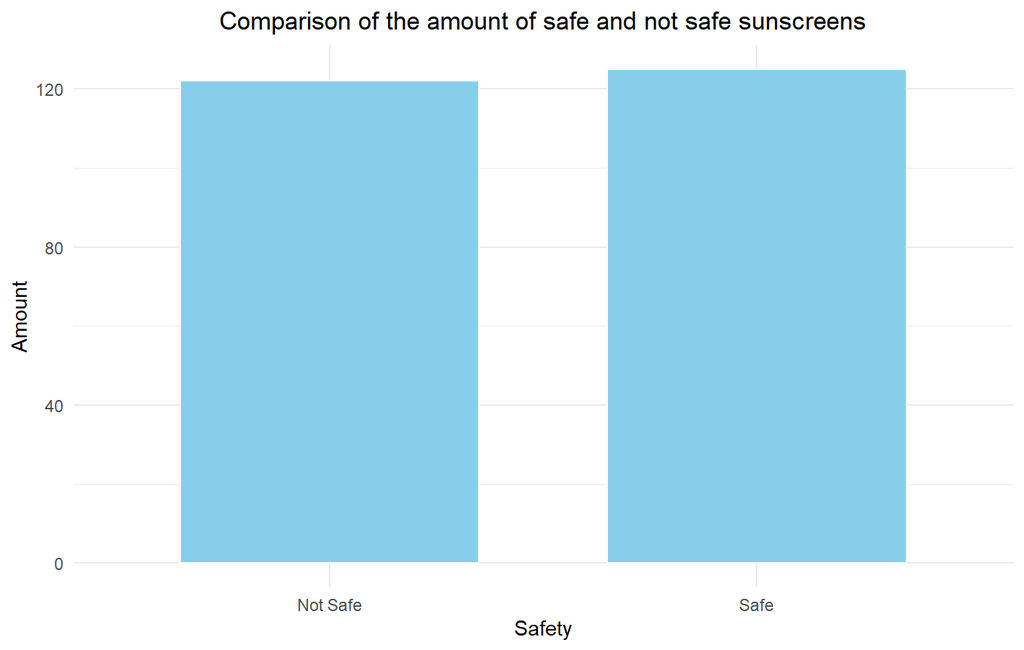

We divided the tanning products available at the website into sunscreens and bronzers. Then we checked how many of the list of 5 harmful ingrdients are in each sunscreen. If the amount was 1 and more the sunscreen was marked “Not Safe”.

b) Bar plot showing the amount of products and star rating categories for tanning products

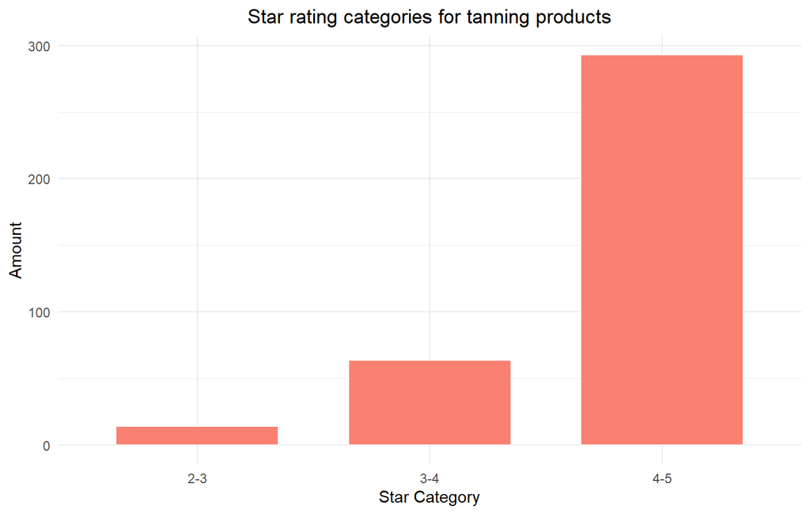

The plot illustrates a notable abundance of products attaining commendable ratings, with a significant majority falling within the elevated range of 4 to 5 stars.

c) Scatter plot showing correlation between stars rating and number of harmful ingredients for sunscreens

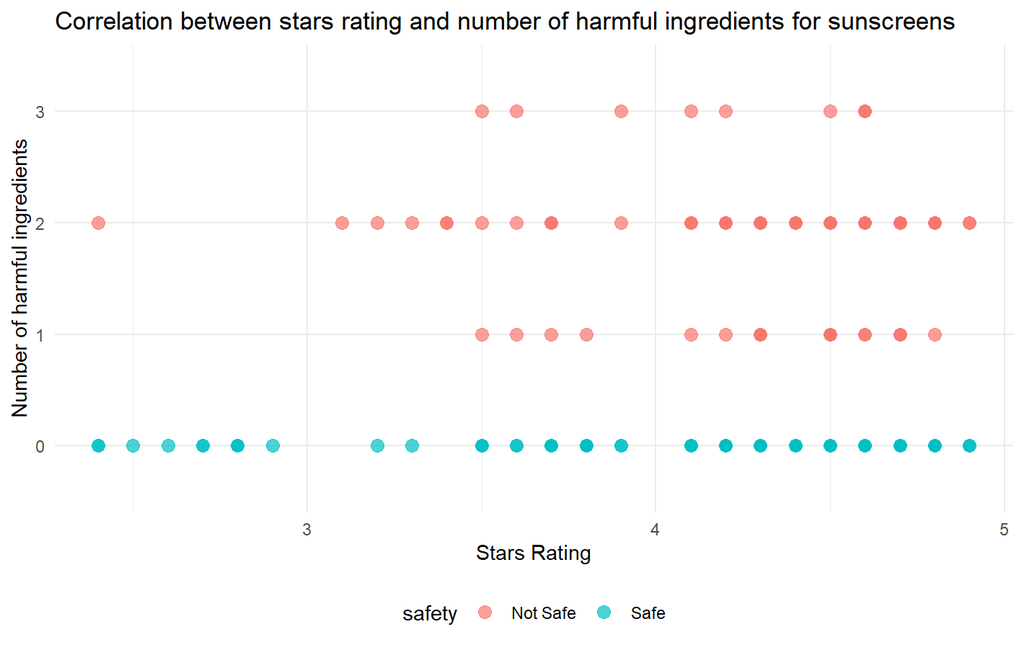

The graph indicates a noteworthy trend wherein sunscreens with the highest ratings often include at least one of the marked “Not Safe” ingredients, signaling a potential correlation between product efficacy, as perceived by users, and the presence of these identified harmful components.

d) Bar plot showing correlation between different price categories and safety for sunscreens

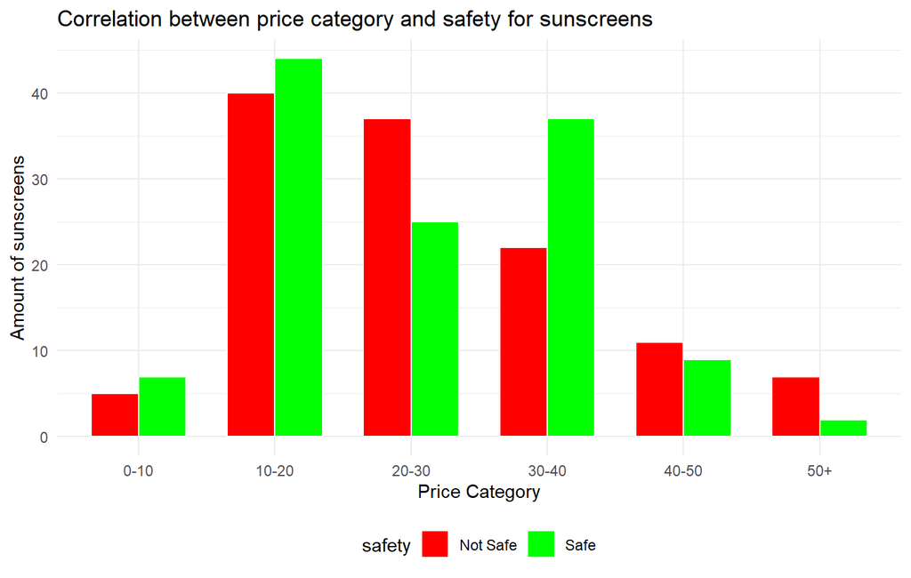

The graph illustrates a distinct pattern where the majority of sunscreens labeled as “safe” are priced within the range of 10-20 dollars, with the second-highest concentration in the 30-40 dollar bracket. In contrast, for products marked as “not safe,” a significant portion is observed in the 10-20 and 20-30 dollar price categories. Interestingly, a considerable number of safe sunscreens are also priced between 30-40 dollars, while a notable proportion of not-safe sunscreens are priced lower. This pricing distribution raises the possibility that individuals may opt for not-safe sunscreens due to their comparatively lower cost.

e) Scatter plot showing correlation between price and number of harmful ingredients

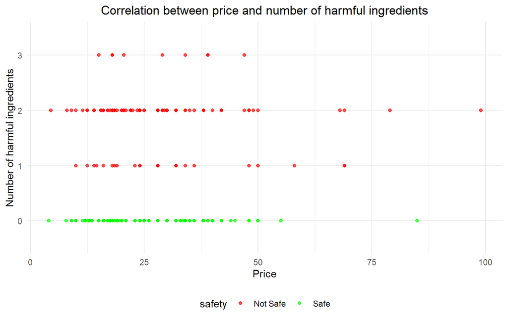

The graph highlights a notable observation that the priciest sunscreen products are predominantly associated with the category of not-safe ingredients. Additionally, a commonality emerges in the pricing structure for both sunscreen groups, with a concentration observed in the 10 to 20 dollar range. However, a distinct trend is discernible as not-safe sunscreens exhibit a greater deviation towards higher prices compared to their safe counterparts.

f) Scatter plot showing correlation between price and reviews amount

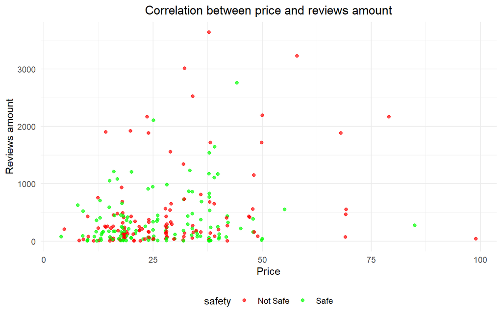

The safe sunscreens display a relatively stable pattern in terms of both review counts and prices. In contrast, the not-safe sunscreens exhibit a tendency to garner a higher number of reviews, suggesting a potential correlation with increased purchase frequency. Notably, the sunscreen with the highest number of reviews belongs to the not-safe category and is priced around 40 dollars, indicative of its popularity despite being in a higher price range.

g) Scatter plot showing correlation between reviews amount and number of harmful ingredients

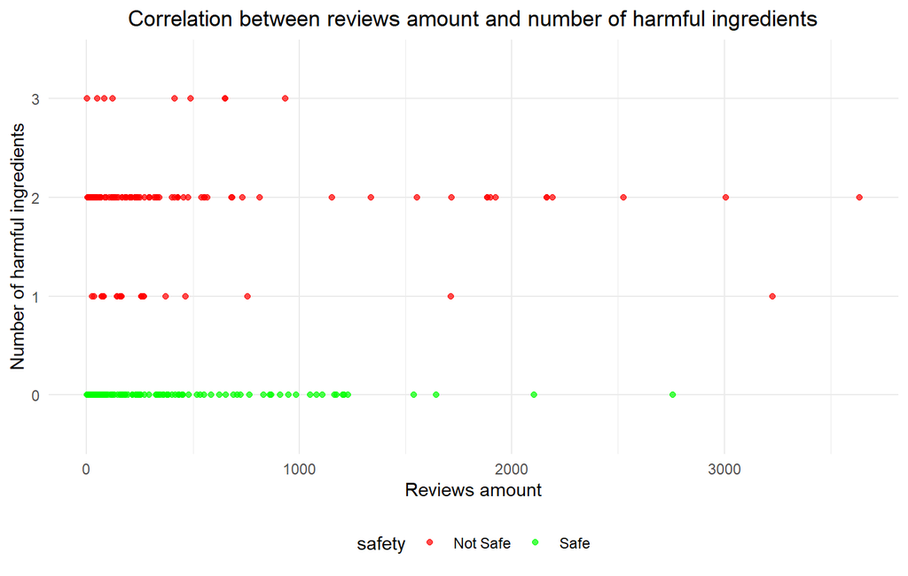

The trend observed in the data reveals that sunscreens with the highest number of harmful ingredients tend to receive fewer reviews. In contrast, those containing two harmful ingredients stand out with the largest number of reviews, suggesting heightened attention and possibly increased usage. Safe sunscreens also exhibit a substantial number of reviews, indicating a noteworthy level of consumer engagement and interest in these products.

h) Bar plot showing amount of products in each price category for tanning products

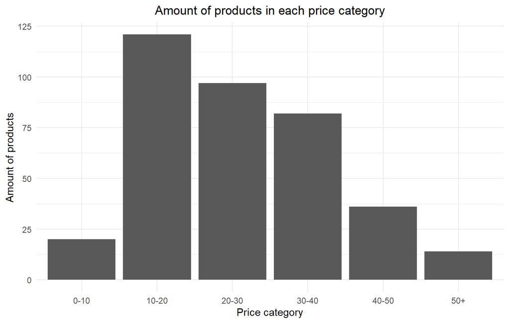

The pricing distribution depicted in the graph illustrates a peak concentration of products falling within the 10-20 dollar range. Following this, there is a descending trend, with fewer products as prices increase. Notably, the least number of products is observed in the category priced over 50 dollars. Additionally, there is a modest representation of the least expensive products, falling within the 0-10 dollar range.

# 4 Conclusions

The data analysis points to several key trends in sunscreen products. High ratings, primarily between 4 and 5 stars, are prevalent, potentially linked to the presence of ingredients marked “Not Safe.” Safe sunscreens are commonly priced between 10-20 dollars, while not-safe ones show a broader pricing distribution with a notable presence in the 10-30 dollar range. The most expensive sunscreens typically contain not-safe ingredients, suggesting a trade-off between safety and cost.

In terms of consumer engagement, products with more harmful ingredients receive fewer reviews, but those with two harmful ingredients attract the highest review counts. Safe sunscreens also garner substantial reviews, indicating consumer interest.

Pricing-wise, the majority of products fall within the 10-20 dollar range, with a declining trend at higher prices. The least represented products are those priced over 50 dollars, while a smaller presence is observed in the 0-10 dollar range. Overall, these insights provide a nuanced understanding of the sunscreen market dynamics.